# satRdays

Steph Locke

2016-04-04

# The Problem

Tech conferences are a vital way of growing the community, especially when the conferences are organised by people from within the community. Like user groups, they provide an essential mechanism for people to network, learn, and develop themselves. Conferences can cover a higher volume and broader scope of content than a user group can. This makes them applicable to people from different industries with varying levels of knowledge around a technology - the ability to cater for this variety is where they can provide a substantial benefit over and above a user group.

In 2015, we saw a bumper number of R conferences. These were:

- General R
  - UseR!, Denmark, ~£400
  - EARL London, UK, ~£400
  - EARL Boston, USA, ~£400
  - Rencontres R, France, ~£120
  - Xian R, China, ~£120
  - Beijing R, China, ~£110
  - New York R conference, USA, ~£350
  - R-omania conference, Romania, ~£75
  - VII Jornadas de Usuarios de R (7th Meeting of Spanish R Users), Spain, **FREE**
- BioConductor
  - BioC 2015, USA, ~£400
  - European BioConductor Developers’ Meeting 2015, Germany, **FREE**
  - European BioConductor Developers’ Meeting 2015, UK, **FREE**
  - BioConductor Asia-Pacific Developer Meeting, Japan, **FREE**
- Industry specific
  - R/Finance, USA, ~£200
  - R in Insurance, Holland, ~£300
  - Psychoco 2015, Holland, **FREE**
  - R Programing Language and Basic Statistics for Research (R2015), Thailand, ~£100

The BioConductor events are typically free but most other R conferences are not. Between the admission costs and the travel costs to reach the relatively few conferences, it puts R conferences out of reach for much of the world. Even in countries where they take place, many people won’t be able to get the budget or sign off to attend. As a result, R conferences have an inherently biased audience and they do not help foster the growth of the R community enough.

Additionally, the limited options do not help us foster local speakers and organisers. Community driven conferences allow for a stronger focus of developing the R ecosystem so that we can help sustain an increasing number of experts and community leaders. These people are essential in facilitating a wider growth in the R user base.

# The proposal

Individual conferences take a long time to get off the ground. It’s an uphill battle to establish an identity, a platform, and an adequate pool of speakers and sponsors. This proposal seeks to address these difficulties by:

1. Providing a brand for R community conferences that can be used by R user groups globally to hold conferences in their region
2. Developing a central site for the hosting and management of the conferences, using and contributing to an existing open-source conference system initiative
3. Holding three trial conferences in the US, EMEA, and another region

This delivers a much needed mechanism for the growth of R conferences globally.

## The brand: satRdays

[figure not shown]

satRdays will be free or cheap conferences held primarily on Saturdays. They will focus on R but the emphasis will be determined by local audience. A satRday will typically be run by one or more user group organisers looking to provide a regional conference.

satRdays are held on weekends to make it easier for people who cannot take the time out of the week to attend, or those who have to travel to the event (like speakers). The maximum cost of £30 per head makes the event much more accessible, and provisions will be put in place to enable free attendance for those that need it.

The specific format of a satRday is up to the individual organisers but it will typically be “standard conference” shaped, with multiple sessions happening simultaneously.

satRdays are community events, so everyone including the speakers will be volunteers.

## The infrastructure: satRdays.org

There will be a central site which is used by satRday organisers to host and manage their conferences. The site will facilitate the:

- Creation of events with templated content
- Customisation of event content by organisers
- Submission of sessions by speakers for consideration
- Selection and scheduling of sessions by organisers
- Registration of attendees
- Hosting of slides etc. from sessions

There are number of open source conference systems out there, and these were evaluated on the following factors:

- How many initial requirements were possible out of the box
- The state of the OS project
- The ability of the proposal participants to extend the system

A Drupal site based on the Conference Organiser Distribution will be used.

## The conferences

There will be three trial conferences in 2016. These will be used to understand factors like existing appetite, speaker availability, optimal session formats, and sponsor appetite. The conferences are anticipated to be held in 2016H2.

The three conferences will be part funded by the R Consortium and the Consortium members can be listed as individual companies for increased brand awareness. They may also charge up to £30 per attendee to cover the rest of the costs.

# Project plan

- Week 0: Announcement blog post
- Week 1: Collaboration platform
- Week 2: Call for organisers
- Week 3: Basic site
- Week 4: Skype call with organisers
- Week 6: Budgets
- Week 8: Venues confirmed
- Week 9: Marketing “Save the dates”
- Week 10: Conference sites
- Week 11: Updated conference sites
- Week 12: Call for speakers
- Week 14: Registration opens
- Week 18: CFS closes
- Week 20: Agendas published
- …
- Week X: Conferences happen

# Requirements

## People

### Central

The infrastructure and brand need some central coordination. Steph Locke will develop the central facilities, and grow the contributors to this area.

### Conferences

Organisers are needed for the three conferences. Gergely Daróczi is our first organiser and will put together a team for his conference.

## Processes

There is a fundamental emphasis on open source within the satRday project. As little as possible will be closed source, and the community at large will be able to contribute to the development. With this in mind, not only will a code of conduct apply to the conferences themselves, but a contributor code of conduct will also apply.

The IP and assets like the satRdays.org domain will need to be transferred to ownership by the R Consortium.

How the financing of the events occurs will also need to be addressed in collaboration with the Consortium. These events are intended to be not for profit so an event organiser should aim for break-even, and to ensure that the Consortium is not left with a big bill, liability for an event will need to sit with individual organisers in some fashion. A rough process for this could be:

1. Organisers deliver an initial budget for their event
2. Funds get allocated from the pool to contribute towards venue & catering costs and are used to **directly** pay or part pay those costs
3. Other funds go to the organiser’s nominated accounts and will be used by them to handle any other costs
4. Post-event organisers deliver provide a budget vs actual report
5. Excess funds go back to the Consortium

## Tools & Tech

- The OS conference system: [Conference Organizing Distribution](http://usecod.com/)
- Site hosting

## Funding

### Central infrastructure

The central site will need hosting. Hosting of the site is expected to cost ~£50 per month.

### Conferences

The trial conferences are expected to have ~600 people attend in total. The requested amount of monetary support for these events is £9,000. This will make the R Consortium (and it’s individual members) main sponsors for the events. The gap between that and estimated cost per delegate of £25-£35 would then be made from either additional sponsors or from small fees to attendees.

## Summary

- On-going hosting costs of <£600 per year
- Initial support of £9,000

# Success

## Definition of done

This project will deliver a coherent brand for community R conferences, a central site, and three conferences.

## Measuring success

Milestones for the technical sides of the project are:

1. Informational site is live
2. Conference site functionality is live

Milestones for each conference are:

1. Location decided
2. Budgets put together
3. Venue confirmed
4. Registration open
5. Agenda published
6. The conference!

## Future work

This infrastructure and first few events give us the potential for greatly developing the R community. It also has a lot of side benefits like being an ideal place to host beginner R labs, showcase developer work, grow the avenues for commercial partners to engage with R users and so forth.

If the events are a success then the model for onging financial support will need to determined. There are a number of (not mutually exclusive) options available:

1. The Consortium members collectively set a budget for the satRdays and members become sponsors of individual events through this global support level - this could be a mechanism for encouraging more Consortium members if sponsorship was exclusively through the Consortium
2. A global sponsorship platform where Consortium members and others could provide sponsorship towards all satRdays
3. Individual events solicit their own sponsorship

## Key risks

Short term, the biggest risks to the project are the organisers of the individual events not pulling it off and the central site being not fit for purpose. Mitigants for this involve a seperation of duties so that noone is over-burdened, and involving the community where possible.

Long term, the biggest risk is a lack of sponsors to make conferences viable. Hopefully, the R ecosystem will continue to grow and commercial partners will see the benefits of conferences, but if that doesn’t happen the ability to charge up to £30 per attendee should be sufficient to maintain a conference so long as they budget appropriately.

# Signatories

## Project team

### Steph Locke

Steph’s a Principal Consultant at Mango Solutions and runs user groups & conferences in her spare time. She runs R, SQL, and .Net user groups in Cardiff, UK, and organises national conferences called SQL Relay. Over the past 3 years she’s organised 25 days of SQL Relay conferences in more than 12 locations. Most recently, Microsoft made her a Data Platform Most Valued Professional for her community work in and around SQL Server and R.

### Gergely Daroczi

Gergely is the maintainer of the `pander` and a few other minor CRAN packages, organizer of the Hungarian R User Group with ~500 members, technical founder of an R and Ruby-on-Rails driven reporting application at rapporter.net, author of an intermediary R book and currently working as a Lead R Developer and Research Data Scientist at CARD.com in Los Angeles.

## Interested parties

```
## No encoding supplied: defaulting to UTF-8.
```

We’ve had tremendous support from the community over the length of developing the proposal. From the first comments on the [initial blog post](http://itsalocke.com/sqlsaturdays-but-for-r/), to active discussion on the [repository](https://github.com/stephlocke/RSaturday-proposal), to 602 people signing up as interested parties within 3 short days towards the end of the proposal development cycle. Below is a breakdown of the interested parties per region:

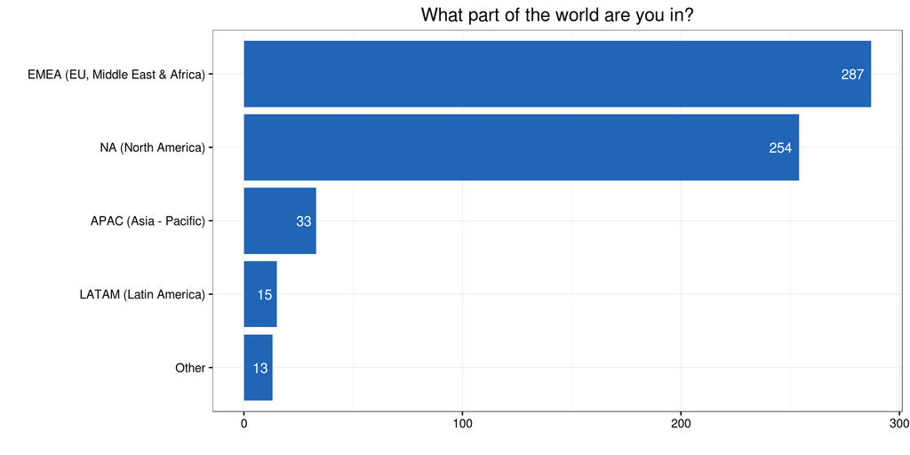

A more detailed breakdown of the location of the interested parties:

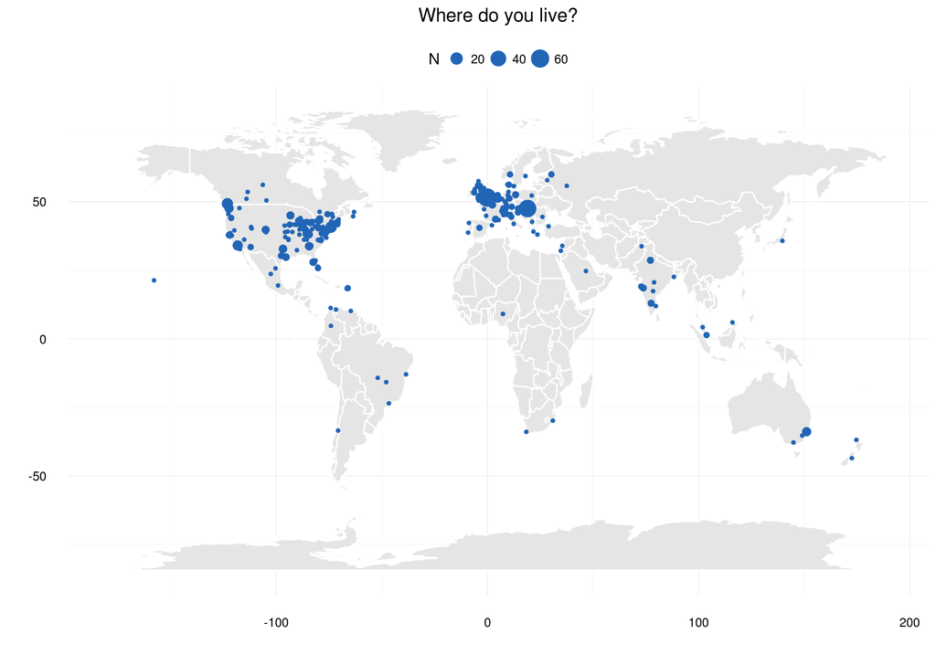

We also asked how far the interested parties are willing to travel for an satRday event:

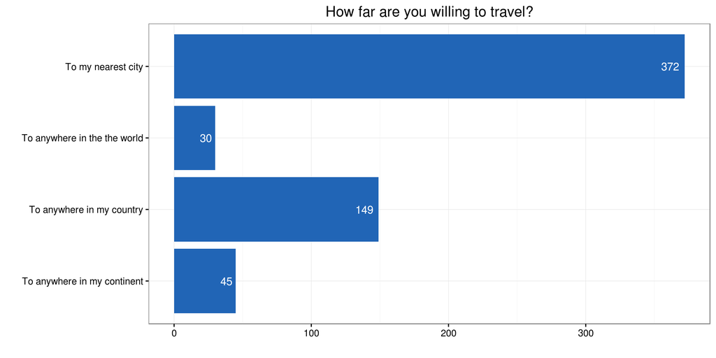

It seems that most respondents are interested in local events, but many (~37%) respondents are willing to travel as well.

Further great news and promising feedback from the community is that the respondents are willing to actively take part in future events:

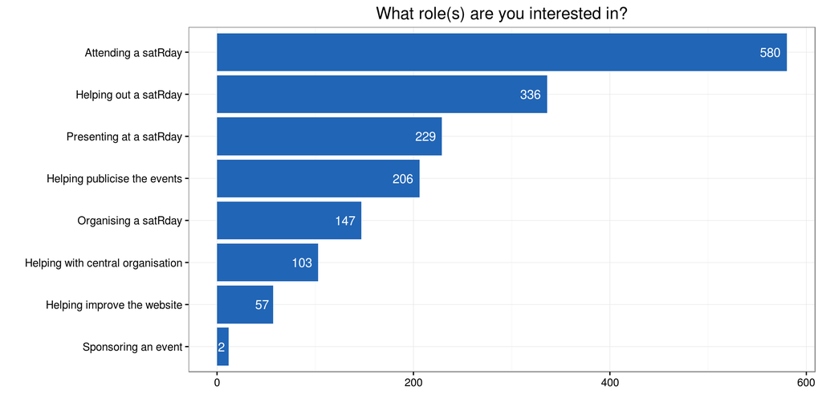